# 7784 Skills: Programming in R

### Kirill Müller, Christoph Sax

### University of St. Gallen, 3.10.2019

# 3.10.: Transformation 1

# Topics for today

1. Admin: Graded assignments, groups

1. Review of assignment

1. Data tranformation with {dplyr}: assignment, pipe, verbs

1. Recap plotting with {ggplot2}: layers, facets

# Admin

## Graded assignments

Early submission useful for monitoring progress, due on 17.10.

## Groups

Possible topics for final report

Happy to help everyone find a group

# Feedback on assignments

## Git

1. Commit messages.
1. Ignoring files.
1. Only commit running code!

## rmarkdown

1. Setup chunk in `.Rmd` file, chunk options.
1. Inline R code.

## Importing

1. Options.

# Material

## Text + scripts

https://krlmlr.github.io/vistransrep/

https://github.com/krlmlr/vistransrep-proj, in `script/` directory

## Exercises

https://krlmlr.github.io/vistransrep/2019-09-unisg/

## Cheat sheets

https://rstudio.com/resources/cheatsheets/

# Material

## Slide decks

https://github.com/rstudio-education/welcome-to-the-tidyverse/blob/master/03-Transform/03-Transform-Slides.pdf, click "Download" for the PDF

https://github.com/rstudio-education/welcome-to-the-tidyverse/raw/master/02-Visualize/02-Visualize-Slides.pdf, click "Download" for the PDF

# Data science workflow

<figure>
  <img src="img/data-science-explore.png">
  <figcaption style="text-align: right; color: #aaa; font-size: small">Source: Wickham and Grolemund</figcaption>
</figure>

# Assignment

`x <- y` pronounced as "`x` _becomes_ `y`"

```r
x <- 3
x
```

```
## [1] 3
```

```r
x <- x + 1
x
```

```
## [1] 4
```

# The pipe

`x %>% f() %>% g()` pronounced as "`x` _then_ `f` _then_ `g`"

```r
f <- function(x) x + 1
g <- function(x) x * 2
```

```r
5 %>% f() %>% g()
```

```
## [1] 12
```

```r
g(f(5))
```

```
## [1] 12
```

```r
## Not:
f(g(5))
```

```
## [1] 11
```

# {dplyr}: Basic pattern

```r
data %>%
  verb(...) %>%
  verb(...) %>%
  ...
```

Each `verb` is a **pure function** (doesn't change its input)!

Use assignment to persist the result:

```r
result <-
  data %>%
  verb(...) ...
```

# Verbs

- `filter()`: Removes rows
- `select()`: Removes and renames columns
- `arrange()`: Reorders
- `mutate()`: Creates variables
- `summarize()`: Computes summaries

## Grouped operations

- `group_by()`: Defines grouping for the next operation

# {ggplot2}: Pattern, revisited

```r
data %>%
  ggplot(aes(...)) +
  geom_...(aes(...), ...) +
  geom_...(aes(...), ...) +
  ... +
  facet_...(...)
```

# Layers

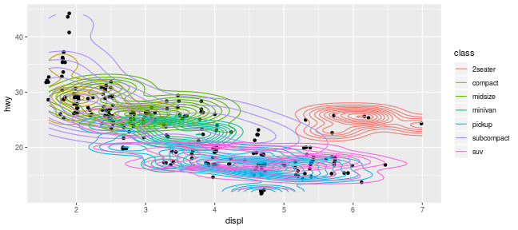

```r
mpg %>%
  ggplot(aes(x = displ, y = hwy)) +
  geom_jitter() +
  geom_density_2d(aes(color = class))
```

# Facets

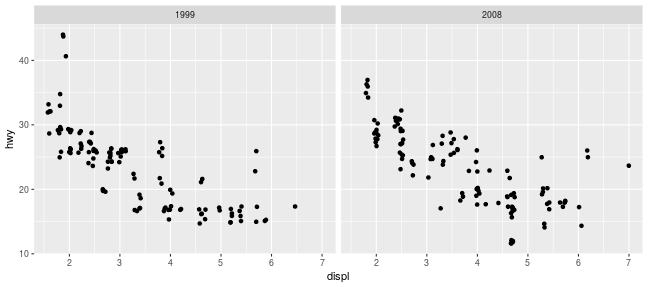

```r
mpg %>%
  ggplot(aes(x = displ, y = hwy)) +
  geom_jitter() +
  facet_wrap(~year)
```

# Pure functions

```r
f <- function(x) { x <- x + 1; x }
g <- function(x) x * 2
```

...never change their inputs!

```r
x <- 3
x %>% f() %>% g()
```

```
## [1] 8
```

```r
x
```

```
## [1] 3
```

```r
y <- x %>% f() %>% g()
y
```

```
## [1] 8
```

```r
x
```

```
## [1] 3
```